# University of Pittsburgh-Pittsburgh Campus (Pittsburgh, PA)

### General information

- Public, 4-year or above
- Doctoral Universities: Very High Research Activity
- Undergraduate enrollment is 23,385 (includes all undergrads; some of the numbers below are based on first time, full time, degree seeking students only).
- Mission: The University of Pittsburgh founded in 1787 is one of the oldest institutions of higher education in the United States. As one of the nation’s distinguished comprehensive universities the resources of the University constitute an invaluable asset for the intellectual economic and social enrichment of Pennsylvania while the international prestige of the University enhances the image of Pennsylvania throughout the world. The University’s mission is to: Provide high-quality undergraduate programs in the arts and sciences and professional fields with emphasis upon those of special benefit to the citizens of Pennsylvania. Offer superior graduate programs in the arts and sciences and the professions that respond to the needs of Pennsylvania as well as to the broader needs of the nation and the world. Engage in research artistic and scholarly activities that advance learning through the extension of the frontiers of knowledge and creative endeavor. Cooperate with industrial and governmental institutions to transfer knowledge in science technology and health care. Offer continuing education programs adapted to the personal enrichment professional upgrading and career advancement interests and needs of adult Pennsylvanians. Make available to local communities and public agencies the expertise of the University in ways that are consistent with the primary teaching and research functions and contribute to social intellectual and economic development in the Commonwealth the nation and the world. The trustees faculty staff students and administration of the University are dedicated to accomplishing this mission to which they pledge their individual and collective efforts determined that the University shall continue to be counted among the prominent institutions of higher education throughout the world.
- 57% of applicants are admitted
- 22% of admitted applicants choose to enroll
- 93% of students stay after their first year
- 83% of students graduate
- The student to all faculty ratio is 14:1
- The student to tenured or tenure-track faculty ratio is 49:1
- Students are required to be vaccinated against COVID-19
- Employees are required to be vaccinated against COVID-19
- This college is located in a large city
- The closest mass transit is a 0 minute walk away
- As of July, 2022, the state this institution is in had abortion restrictions categorized “restrictive” by the [Guttmacher Institute](https://states.guttmacher.org/policies/), though this may change.
- Athletic conference: Atlantic Coast Conference

# Details

## Tables

### Degrees awarded each year

| Degree | Number |
| --- | --- |
| Associate | 2 |
| Bachelor | 4694 |
| Master | 1994 |
| Doctor | 1113 |

### Diversity among the faculty

Two things to note here are diversity overall as well as the distribution tenure, tenure track, and non tenure track faculty. There are two main tracks in academia: faculty who are given short term contracts (and often a high teaching load and lower pay) and faculty who are essentially on probation (for 3-6 years, typically) and then are given tenure or fired. For more about tenure, see [here](https://www.aaup.org/issues/tenure). Tenure is a way of protecting academic freedom (tenured faculty can be fired for misconduct or if a program is closed, but not for their research or speech); the fact that it is often more stable also helps ensure that faculty will be at an institution long term to serve as mentors, letter writers, etc. Having more non-tenure-track faculty can save money (they are often paid less, and teach more), reduce public dissent (they can be fired for taking a stand unpopular with their employer), and reduce research or other creative output, including mentoring in these areas (teaching loads are often higher, and research/creative output expectations lower, for faculty in non-tenure-track positions at large universities).

|  | Tenured (count) | Tenure-track (count) | Non-tenure-track (count) | Tenured (percent) | Tenure-track (percent) | Non-tenure-track (percent) |
| --- | --- | --- | --- | --- | --- | --- |
| Grand total men | 812 | 267 | 1340 | 19.1% | 6.3% | 31.5% |
| Grand total women | 351 | 186 | 1303 | 8.2% | 4.4% | 30.6% |
| American Indian or Alaska Native men | 0 | 0 | 1 | 0% | 0% | 0% |
| American Indian or Alaska Native women | 0 | 0 | 2 | 0% | 0% | 0% |
| Asian men | 152 | 55 | 267 | 3.6% | 1.3% | 6.3% |
| Asian women | 63 | 23 | 203 | 1.5% | 0.5% | 4.8% |
| Black or African American men | 13 | 13 | 36 | 0.3% | 0.3% | 0.8% |
| Black or African American women | 14 | 9 | 42 | 0.3% | 0.2% | 1% |
| Hispanic or Latino men | 26 | 8 | 34 | 0.6% | 0.2% | 0.8% |
| Hispanic or Latino women | 12 | 7 | 41 | 0.3% | 0.2% | 1% |
| Native Hawaiian or Other Pacific Islander men | 1 | 0 | 3 | 0% | 0% | 0.1% |
| Native Hawaiian or Other Pacific Islander women | 1 | 0 | 1 | 0% | 0% | 0% |
| White men | 613 | 150 | 898 | 14.4% | 3.5% | 21.1% |
| White women | 260 | 119 | 949 | 6.1% | 2.8% | 22.3% |
| Two or more races men | 3 | 2 | 7 | 0.1% | 0% | 0.2% |
| Two or more races women | 0 | 3 | 2 | 0% | 0.1% | 0% |
| Race/ethnicity unknown men | 2 | 1 | 8 | 0% | 0% | 0.2% |
| Race/ethnicity unknown women | 0 | 2 | 8 | 0% | 0% | 0.2% |
| Nonresident alien men | 2 | 38 | 86 | 0% | 0.9% | 2% |
| Nonresident alien women | 1 | 23 | 55 | 0% | 0.5% | 1.3% |

### Diversity among the students

|  | Undergrad (count) | Grad student (count) | Undergrads (percent) | Grad students (percent) |
| --- | --- | --- | --- | --- |
| Grand total men | 8488 | 3205 | 46.2% | 44% |
| Grand total women | 9904 | 4077 | 53.8% | 56% |
| American Indian or Alaska Native men | 4 | 3 | 0% | 0% |
| American Indian or Alaska Native women | 6 | 2 | 0% | 0% |
| Asian men | 836 | 180 | 4.5% | 2.5% |
| Asian women | 1256 | 284 | 6.8% | 3.9% |
| Black or African American men | 392 | 100 | 2.1% | 1.4% |
| Black or African American women | 548 | 201 | 3% | 2.8% |
| Hispanic men | 410 | 153 | 2.2% | 2.1% |
| Hispanic women | 507 | 170 | 2.8% | 2.3% |
| Native Hawaiian or Other Pacific Islander men | 1 | 3 | 0% | 0% |
| Native Hawaiian or Other Pacific Islander women | 2 | 0 | 0% | 0% |
| White men | 5938 | 1405 | 32.3% | 19.3% |
| White women | 6544 | 2165 | 35.6% | 29.7% |
| Two or more races men | 340 | 67 | 1.8% | 0.9% |
| Two or more races women | 487 | 115 | 2.6% | 1.6% |
| Race/ethnicity unknown men | 84 | 145 | 0.5% | 2% |
| Race/ethnicity unknown women | 91 | 211 | 0.5% | 2.9% |
| Nonresident alien men | 483 | 1149 | 2.6% | 15.8% |
| Nonresident alien women | 463 | 929 | 2.5% | 12.8% |

### US student origins

First time degree seeking undergrads

| State | Number of students | Fraction of student body from each state | Fraction of 18 year olds from each state enrolled here |
| --- | --- | --- | --- |
| Alabama | 1 | 1/3802 | 1/62938 |
| Alaska | 2 | 1/1901 | 1/4259 |
| Arizona | 6 | 1/634 | 1/16287 |
| Arkansas | 1 | 1/3802 | 1/38933 |
| California | 67 | 1/57 | 1/7690 |
| Colorado | 5 | 1/760 | 1/14663 |
| Connecticut | 25 | 1/152 | 1/2009 |
| Delaware | 23 | 1/165 | 1/547 |
| Florida | 42 | 1/91 | 1/5765 |
| Georgia | 29 | 1/131 | 1/4905 |
| Hawaii | 2 | 1/1901 | 1/7488 |
| Idaho | 1 | 1/3802 | 1/24523 |
| Illinois | 56 | 1/68 | 1/2852 |
| Indiana | 9 | 1/422 | 1/9872 |
| Iowa | 1 | 1/3802 | 1/41858 |
| Kansas | 2 | 1/1901 | 1/19566 |
| Kentucky | 3 | 1/1267 | 1/19011 |
| Louisiana | 2 | 1/1901 | 1/29008 |
| Maine | 6 | 1/634 | 1/2675 |
| Maryland | 144 | 1/26 | 1/547 |
| Massachusetts | 67 | 1/57 | 1/1460 |
| Michigan | 25 | 1/152 | 1/5319 |
| Minnesota | 1 | 1/3802 | 1/70682 |
| Mississippi | 1 | 1/3802 | 1/39907 |
| Missouri | 1 | 1/3802 | 1/74065 |
| Montana | 0 | 0 | 0 |
| Nebraska | 1 | 1/3802 | 1/25694 |
| Nevada | 2 | 1/1901 | 1/17656 |
| New Hampshire | 8 | 1/475 | 1/2165 |
| New Jersey | 314 | 1/12 | 1/348 |
| New Mexico | 3 | 1/1267 | 1/9220 |
| New York | 239 | 1/16 | 1/1025 |
| North Carolina | 25 | 1/152 | 1/5663 |
| North Dakota | 0 | 0 | 0 |
| Ohio | 85 | 1/45 | 1/1784 |
| Oklahoma | 3 | 1/1267 | 1/16913 |
| Oregon | 4 | 1/950 | 1/12347 |
| Pennsylvania | 2395 | 1/2 | 1/70 |
| Rhode Island | 9 | 1/422 | 1/1760 |
| South Carolina | 2 | 1/1901 | 1/30833 |
| South Dakota | 0 | 0 | 0 |
| Tennessee | 11 | 1/346 | 1/7613 |
| Texas | 40 | 1/95 | 1/10033 |
| Utah | 1 | 1/3802 | 1/49459 |
| Vermont | 4 | 1/950 | 1/2303 |
| Virginia | 115 | 1/33 | 1/951 |
| Washington | 2 | 1/1901 | 1/44368 |
| West Virginia | 10 | 1/380 | 1/2116 |
| Wisconsin | 7 | 1/543 | 1/10738 |
| Wyoming | 0 | 0 | 0 |

### Library resources

[output not shown]

## Figures

### Student to faculty ratio compared to similar institutions:

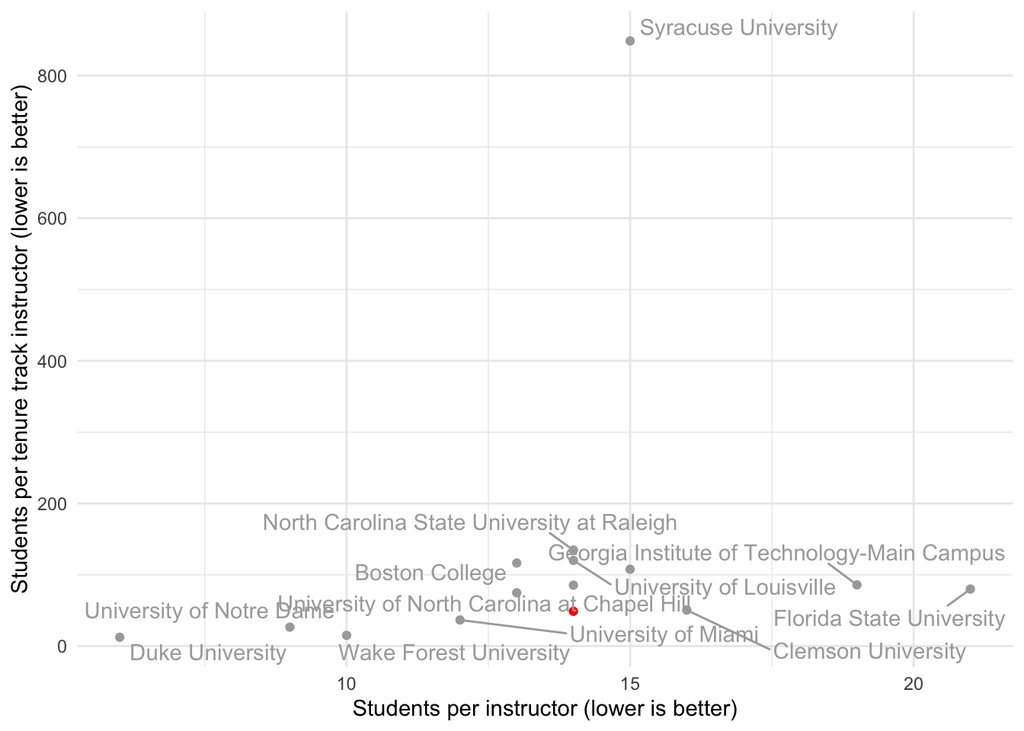

### Students from US

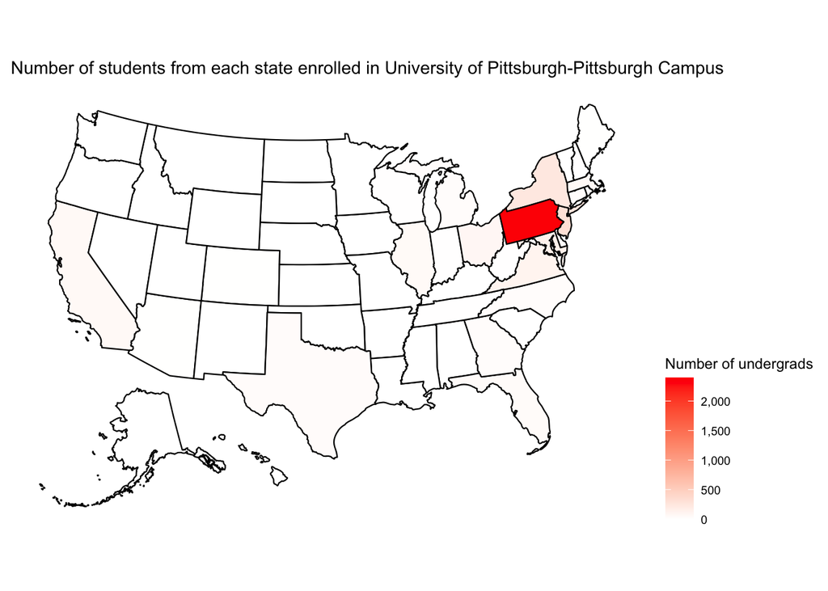

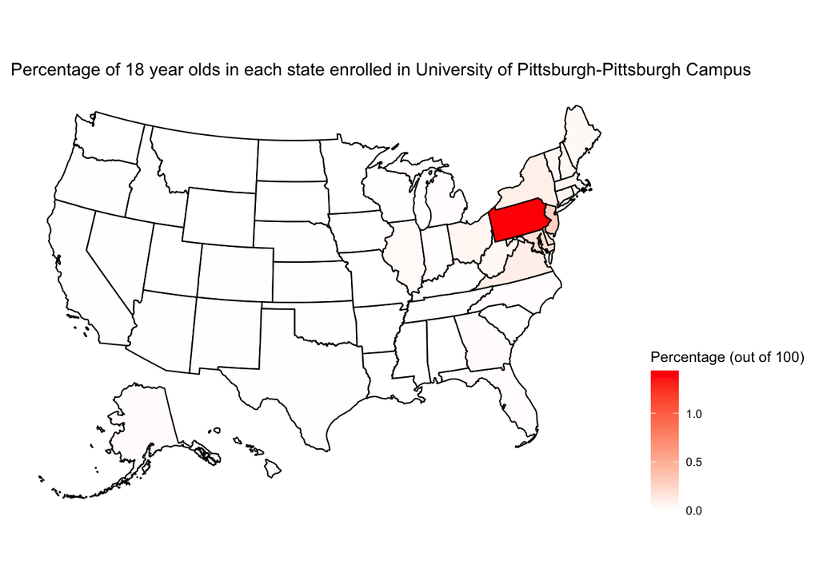